# lab4cp1

## Problema 4 - lab 01

Neste laboratório estaremos trabalhando o problema de amostragem. Nosso *dataset* é uma amostra de atividades no GitHub com a contagem de quantas pessoas editaram arquivos com cada extensão em cada dia de 2016 e 2017. Como já estamos trabalhando com uma amostra, utilizaremos a técnica de *bootstrap* para criar outras amostras tendo como base nossa amostra principal. Assim simulamos o que seria desejável realizar na prática, se fosse possível, que seria a coleta de várias amostras para melhor representar uma população.

Para responder as questões do lab, iremos escolher as linguagem Python e Java, por serem largamente usadas e por já termos tido mais contato com elas no passado.

```r
github = read_csv(file = "../data/github-users-committing-filetypes.csv")
names(github)
```

```
## [1] "file_extension" "month_day"      "the_month"      "the_year"
## [5] "users"
```

```r
github = github %>%
    mutate(
      date = lubridate::ymd(paste(the_year, the_month, month_day)),
                  week_day = lubridate::wday(date))

py = github %>%
  filter(file_extension %in% c("py")) %>%
  mutate(isWeekend = if_else(week_day %in% c("1","7"), TRUE, FALSE))

java = github %>%
  filter(file_extension %in% c("java")) %>%
  mutate(isWeekend = if_else(week_day %in% c("1","7"), TRUE, FALSE))

py_java = github %>%
  filter(file_extension %in% c("java", "py"), !(week_day %in% c("1","7")))

#py_java_weekday = py_java %>%
#  filter(!(week_day %in% c("1","7")))

#py_java_weekend = py_java %>%
#  filter(week_day %in% c("1","7"))
```

## Breve EDA

Para cada uma das linguagens analisadas temos 496 registros.

#### Como é a distribuição de users por linguagem? (ajuda a explicar pq usar media ou mediana mais a frente)

```r
p = ggplot(py_java, aes(x = file_extension, y = users)) +
  geom_boxplot(varwidth = TRUE)
ggplotly(p)
```

[interactive chart not shown]

Observamos que a linguagem Python tem maior quantidade de arquivos editados e diria que não temos *outiliers* estranhos ao contexto. Apenas dias que tiveram menos usuários fazendo edições quando comparados com a maioria, mas não fora do normal.

#### Os meses de 2016 tem uma frequência de trabalho parecida?

```r
users_per_month_2016 = py_java %>%
  filter(the_year == 2016) %>%
  group_by(file_extension, the_month) %>%
  summarise(total_users = sum(users))

p = users_per_month_2016 %>%
  ggplot(aes(x=as.factor(the_month), y=total_users, fill=file_extension)) +
  geom_bar(stat="identity", position=position_dodge()) +
  scale_x_discrete("Meses de 2016",
    breaks = c(1, 2, 3, 4, 5, 6, 7, 8, 9, 10, 11, 12),
    label = c("Jan", "Fev", "Mar", "Abr", "Maio", "Jun", "Jul", "Ago", "Set", "Out", "Nov", "Dez")) +
  scale_y_continuous("Total de usuários") +
  scale_fill_discrete("Linguagem")
ggplotly(p)
```

[interactive chart not shown]

Aqui confirma o boxplot visto anteriormente, com Python liderando com maior número de usuários que editaram arquivos de sua linguagem. E podemos dizer que não temos um mês “diferentão” dos demais, mas curiosamente o padrão visto durante os meses para Python é bem parecido para Java. Será influência das férias ou períodos festivos do ano?

#### Os meses de 2016 tem uma frequência de trabalho parecida com os de 2017?

Abaixo vamos comparar os meses de Janeiro a Abril de 2016 e de 2017 para as duas linguagens. Será feito até Abril porque os dados referentes à Maio de 2017 não são completos e além desses ainda nem existem.

```r
month_summ = py_java %>%
  group_by(file_extension, the_month, the_year) %>%
  summarise(total_users = sum(users))

# comparacao 2016/2017 para java
p = month_summ %>%
  filter(file_extension == "java", the_month <= 4) %>%
  ggplot(aes(x=as.factor(the_month), y=total_users, fill=as.factor(the_year))) +
  geom_bar(stat="identity", position=position_dodge()) +
  scale_x_discrete("Mês",
    breaks = c(1, 2, 3, 4),
    label = c("Jan", "Fev", "Mar", "Abr")) +
  scale_y_continuous("Total de usuários") +
  scale_fill_discrete("Ano")
ggplotly(p)
```

[interactive chart not shown]

```r
# comparacao 2016/2017 para py
p = month_summ %>%
  filter(file_extension == "py", the_month <= 4) %>%
  ggplot(aes(x=as.factor(the_month), y=total_users, fill=as.factor(the_year))) +
  geom_bar(stat="identity", position=position_dodge()) +
  scale_x_discrete("Mês",
    breaks = c(1, 2, 3, 4),
    label = c("Jan", "Fev", "Mar", "Abr")) +
  scale_y_continuous("Total de usuários") +
  scale_fill_discrete("Ano")
ggplotly(p)
```

[interactive chart not shown]

É possível notar apenas que em 2017 houve uma diminuição do número de usuários que alteraram arquivos .py ou .java.

## Questão 1

Como não vimos nenhuma entrada que comprometa a análise por ter valor muito estranho ou errôneo, vamos utilizar como medida de comparação a média, para nos indicar a quantidade média de usuários que alteraram arquivos .py ou .java nos períodos de tempo estudados.

#### Sobre java: há uma diferença significativa na sua popularidade durante os dias de semana e durante o fim de semana?

Nesta primeira etapa usaremos bootstrap nos dados java durante a semana e durante o final de semana separadamente, para definirmos um intervalo para a estimativa da média com 90% de confiança.

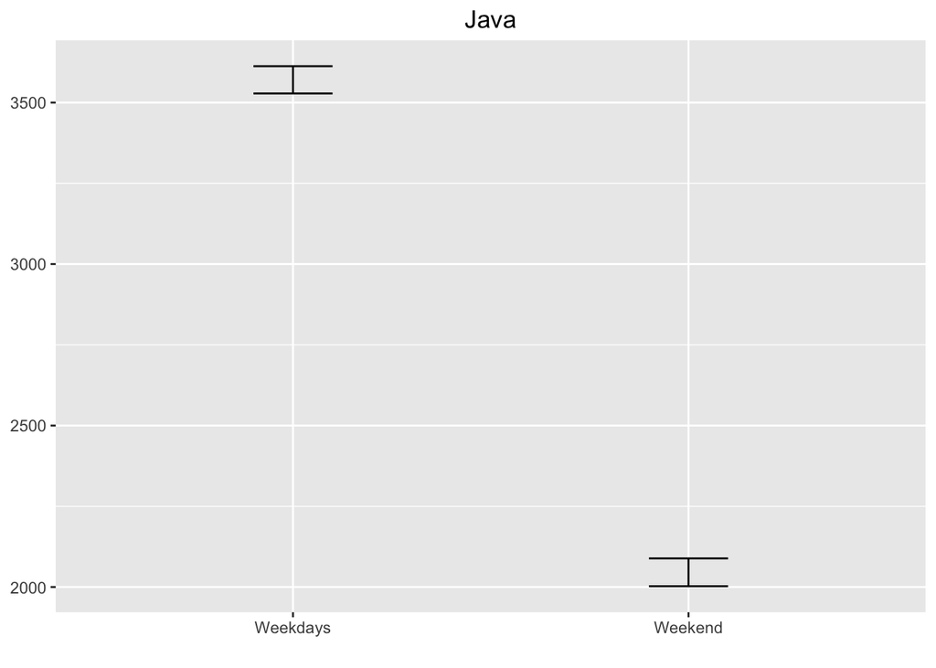

```r
# Java - bootstrap simples
java_weekend = java %>%
  filter(isWeekend == TRUE)

java_week = java %>%
  filter(isWeekend == FALSE)

java_weekend_mean =  bootstrap(data = java_weekend$users, statistic=mean)
java_week_mean = bootstrap(data = java_week$users, statistic = mean)

java_week_CI = CI.percentile(java_week_mean, probs = c(.05, .95))
java_weekend_CI = CI.percentile(java_weekend_mean, probs = c(.05, .95))

data.frame(rbind(java_week_CI, java_weekend_CI)) %>%
  ggplot(aes(x = c("Weekdays", "Weekend"), ymin = X5., ymax = X95.)) +
  geom_errorbar(width = .2) +
  ggtitle("Java") +
  theme(plot.title = element_text(hjust = 0.5)) +
  labs(x="")
```

```r
show(java_week_CI)
```

```
##            5%      95%
## mean 3528.254 3612.728
```

```r
show(java_weekend_CI)
```

```
##            5%      95%
## mean 2002.564 2088.689
```

Nessa segunda parte calculamos, também utilizando bootstrap e com confiança de 90%, a estimativa da diferença da média entre a semana e o fim de semana.

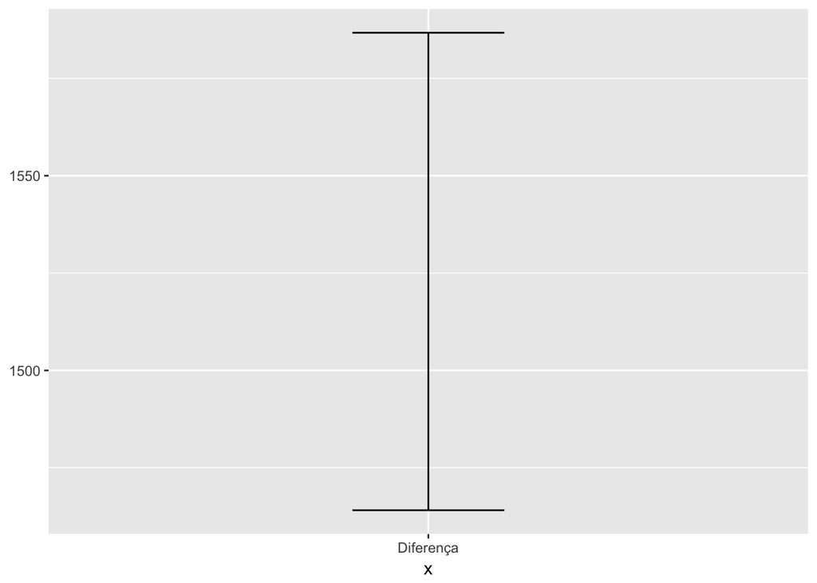

```r
# Bootstrap calculando a diferenca
# Calcula a diferenca entre fim de semana e dia de semana utilizando a media de users para cada amostragem gerada pelo bootstrap
b.diff.means = bootstrap2(java$users,
                          mean,
                          treatment = java$isWeekend) # 10000 amostragens por padrão

means.diff = CI.percentile(b.diff.means, probs = c(.05, .95)) #confianca de 90%

data.frame(means.diff) %>%
  ggplot(aes(x = "Diferença", ymin = X5., ymax = X95.)) +
  geom_errorbar(width = .2)
```

```r
  #geom_hline(yintercept = 0, colour = "darkorange") # o intervalo intercepta o 0? Se sim, não se pode afirmar nada
```

Obtivemos como resposta do processo o intervalo que vai de 1462 a 1586 para a diferença. O que quando comparado com os limites visto anteriormente, faz sentido!

#### Sobre python: há uma diferença significativa na sua popularidade durante os dias de semana e durante o fim de semana?

Para Python repetiremos o processo de maneira análoga.

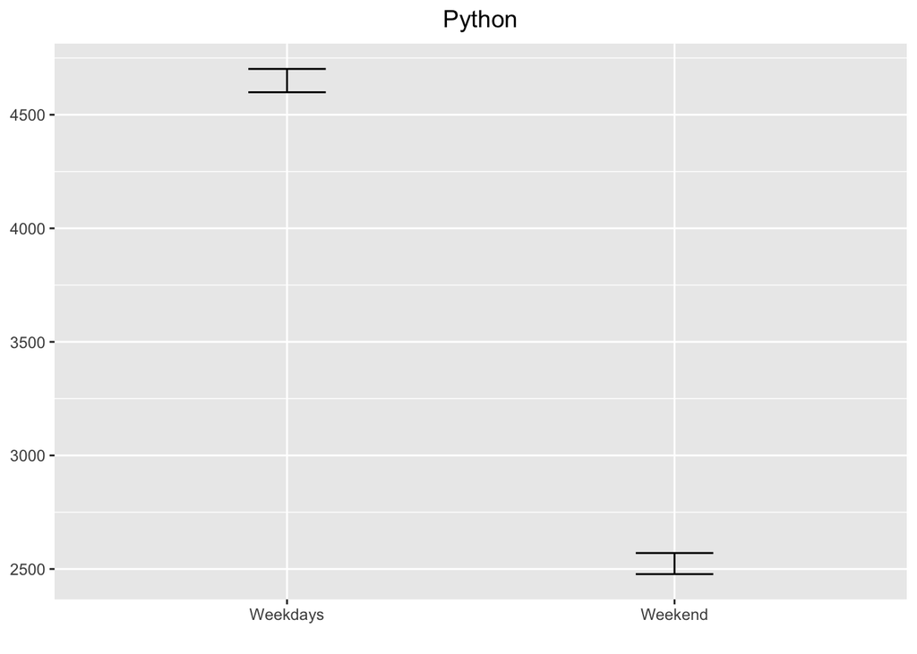

```r
# Python - bootstrap simples
py_weekend = py %>%
  filter(isWeekend == TRUE)

py_week = py %>%
  filter(isWeekend == FALSE)

py_weekend_mean = bootstrap(data = py_weekend$users, statistic = mean)
py_week_mean = bootstrap(data = py_week$users, statistic = mean)

py_week_CI = CI.percentile(py_week_mean, probs = c(.05, .95))
py_weekend_CI = CI.percentile(py_weekend_mean, probs = c(.05, .95))

data.frame(rbind(py_week_CI, py_weekend_CI)) %>%
  ggplot(aes(x = c("Weekdays", "Weekend"), ymin = X5., ymax = X95.)) +
  geom_errorbar(width = .2) +
  ggtitle("Python") +
  theme(plot.title = element_text(hjust = 0.5)) +
  labs(x="")
```

Encontramos como intervalo para a média da semana os valores entre 4599 e 4701, e para o fim de semana o intervalo 2478 a 2570.

```r
# Bootstrap calculando a diferenca
# Calcula a diferenca entre fim de semana e dia de semana utilizando a media de users para cada amostragem gerada pelo bootstrap
b.diff.means = bootstrap2(py$users,
                          mean,
                          treatment = py$isWeekend) # 10000 amostragens por padrão

means.diff = CI.percentile(b.diff.means, probs = c(.05, .95)) #confianca de 90%
means.diff
```

```
##                        5%      95%
## mean: FALSE-TRUE 2056.261 2194.181
```

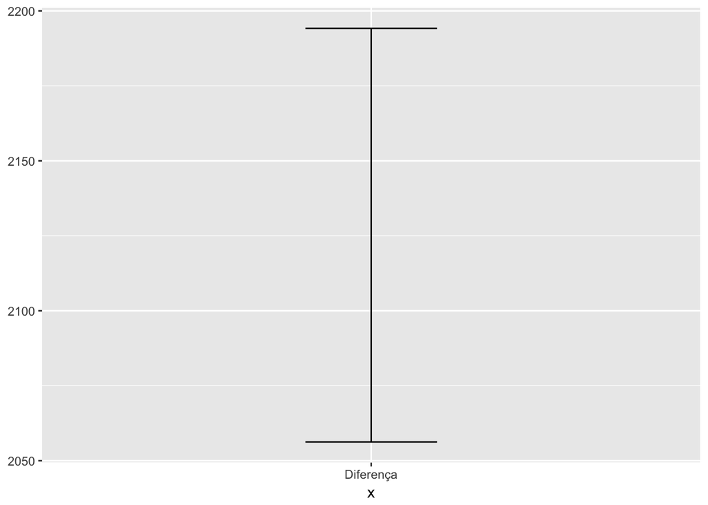

```r
data.frame(means.diff) %>%
  ggplot(aes(x = "Diferença", ymin = X5., ymax = X95.)) +
  geom_errorbar(width = .2)
```

```r
  # geom_hline(yintercept = 0, colour = "darkorange") # o intervalo intercepta o 0? Se sim, não se pode afirmar nada
```

Para o intervalo da diferença obtivemos de 2056 a 2194. O que mais uma vez bate com as informações anteriores.

# Questão 2

#### Existe uma diferença significativa na variação da popularidade das duas quando você compara o quanto a popularidade de cada uma varia durante os dias da semana?

Aqui observaremos a diferença da variação da popularidade entre as linguagens durante os dias de semana.

```r
# Diferenca do desvio padrao da qtd de users que contribuiram durante os dias de semana para as duas linguagens
b.diff.sd = bootstrap2(py_java$users,
                          sd,
                          treatment = py_java$file_extension) # 10000 amostragens por padrão

sd.diff = CI.percentile(b.diff.sd, probs = c(.05, .95)) #confianca de 90%
sd.diff
```

```
##                    5%       95%
## sd: java-py -170.4788 -25.79164
```

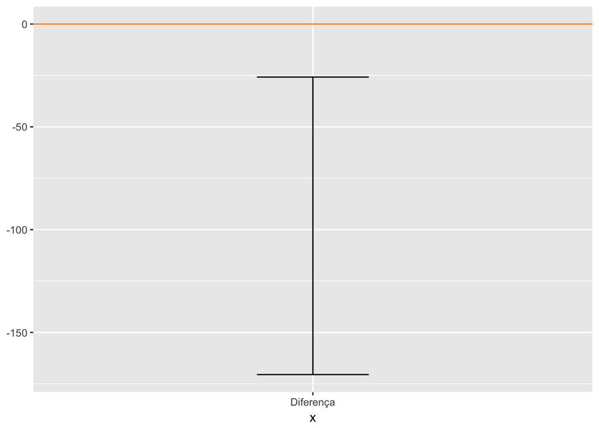

```r
data.frame(sd.diff) %>%
  ggplot(aes(x = "Diferença", ymin = X5., ymax = X95.)) +
  geom_errorbar(width = .2) +
  geom_hline(yintercept = 0, colour = "darkorange") # o intervalo intercepta o 0? Se sim, não se pode afirmar nada
```

Encontramos um intervalo com valores negativos, o que nos indica que java tem menor variação da popularidade durante a semana, uma vez que o bootstrap calculou a diferença subtraindo a variação de python da variação de java.

```r
show(sd.diff)
```

```
##                    5%       95%
## sd: java-py -170.4788 -25.79164
```